# MATH2319_Assignment_Part1

Samuel Holt (s3381728) and Margaret Cuddihy (s3608125)

28 April 2019

# Introduction

The data set chosen for machine learning training is Google advertising data.

The data set was made available on Kaggle as part of the MATH2319 competition and was accessed from the following link: https://www.kaggle.com/c/machine-learning-battle-mlmath2319/data

#### Goal

By training a machine learning algorithm to the descriptive features in the data set, the target feature, a revenue metric labelled as y, can be predicted. Hence, the purpose of training a machine learning algorithm to this data set is that Google will be able to better predict the advertising specifications that optimise returns on clicks and potentially improve revenue returns.

For this first phase of the project, the objective is to inspect the data items in the data set in order to gain an understanding of each feature’s behaviour and to highlight any significant relationships between features. This understanding will guide the strategy of the second phase of the project where the machine learning algorithm is designed and tested. This initial inspection will also aim to identfy any data quality issues that will be appropriately handled before machine learning modelling begins.

#### Description of the Data Set

The dataset instances are comprised of website traffic records from around the world. Descriptive features include:

- companyId: - Company ID of record (categorical)
- countryId: - Country ID of record (categorical)
- deviceType: - Device type of record (categorical corresponding to desktop, mobile, tablet)
- day: -Day of record (integer between 1 (oldest) and 30 for train, 31 and 35 (most recent) for test)
- dow: - Day of week of the record (categorical)
- price1, price2, price3: - Price combination for the record set by the company (numeric)
- ad_area: - area of advertisement (normalized between 0 and 1)
- ad_ratio: - ratio of advertisement’s length to its width (normalized between 0 and 1)
- requests, impression, cpc, ctr, viewability: - Various metrics related to the record (numeric)
- ratio1 - ratio5: - Ratio characteristics related to the record (each normalized between 0 and 1)
- y (target feature): - revenue-related metric (numeric)

The currency features are in US Dollars.

#### Structure of Phase 1

First, the data will be inspected, and any necessary pre-processing will be undertaken to ensure the data set is clean and ready for modelling.

1. Data structure and dimensions will be determined
2. Data will be checked for any missing or special values which will be appropriately imputed
3. Data will be checked for outliers which will be handled as necessary

Second, the descriptive features of the data will be explored in order to identify significant relationships between features that will guide the machine learning modelling. For instance, descriptive features with strong correlation may be redundant to predictive modelling.

1. Distribution of descriptive feature levels will be examined
2. Correlation between descriptive features will be calculated
3. Correlation between descriptive features and the target feature will be calculated

The aim of this is to identify the descriptive features most useful for predicting the target variable, the revenue metric y.

## Packages

```r
 library(dplyr)
# library(tidyr)
 library(knitr)
```

```r
# library(mlr)
# library(outliers)
library(ggplot2)
library(Hmisc)
library(corrplot)
```

# Reading and Inspecting the Data

```r
advertising_train <- read.csv("~/Uni/Machine Learning/advertising_train.csv", header = TRUE, stringsAsFactors = FALSE)

head(advertising_train)
```

```
##   case_id companyId countryId deviceType day      dow price1 price2 price3
## 1       1        95       234          1   1 Saturday   0.11   0.30 0.6000
## 2       2        43        57          2   1 Saturday   0.00   0.00 0.0000
## 3       3        43        57          2   1 Saturday   0.78   1.10 2.1786
## 4       4        43        57          2   1 Saturday   0.78   1.10 2.1786
## 5       5        43        29          2   1 Saturday   4.56   4.56 4.5626
## 6       6        43        29          2   1 Saturday   0.00   0.00 0.0000
##   ad_area ad_ratio requests impression    cpc    ctr viewability ratio1
## 1  7.5000  0.83333    10577       4350 0.6291 0.0011      0.0557 0.8630
## 2 24.2500  0.25773     1023       1023 0.1887 0.0039      0.4495 1.0000
## 3 24.2500  0.25773        0          0 0.0000 0.0000      0.0000 0.0000
## 4 24.2500  0.25773     4967       1038 0.5028 0.0019      0.1883 0.6474
## 5  0.0001  1.00000     1487         27 0.0093 0.4444      0.8750 1.0000
## 6  0.0001  1.00000       15          9 0.0012 0.1111      1.0000 1.0000
##   ratio2 ratio3 ratio4 ratio5          y
## 1 0.4811 0.0646 0.3097 0.6257 0.25011088
## 2 0.6109 1.0000 0.0000 0.0000 0.81657143
## 3 0.0000 0.0000 0.0000 0.0000 1.03548387
## 4 0.9595 1.0000 0.0000 0.0000 0.35180674
## 5 1.0000 1.0000 0.0000 0.0000 0.06790124
## 6 1.0000 1.0000 0.0000 0.0000 0.15000000
```

```r
dim(advertising_train)
```

```
## [1] 214128     22
```

```r
str(advertising_train)
```

```
## 'data.frame':    214128 obs. of  22 variables:
##  $ case_id    : int  1 2 3 4 5 6 7 8 9 10 ...
##  $ companyId  : int  95 43 43 43 43 43 43 43 159 159 ...
##  $ countryId  : int  234 57 57 57 29 29 29 29 234 234 ...
##  $ deviceType : int  1 2 2 2 2 2 2 2 2 2 ...
##  $ day        : int  1 1 1 1 1 1 1 1 1 1 ...
##  $ dow        : chr  "Saturday" "Saturday" "Saturday" "Saturday" ...
##  $ price1     : num  0.11 0 0.78 0.78 4.56 0 0 0 1 0 ...
##  $ price2     : num  0.3 0 1.1 1.1 4.56 0 0 0 1.86 0 ...
##  $ price3     : num  0.6 0 2.18 2.18 4.56 ...
##  $ ad_area    : num  7.5 24.25 24.25 24.25 0.0001 ...
##  $ ad_ratio   : num  0.833 0.258 0.258 0.258 1 ...
##  $ requests   : int  10577 1023 0 4967 1487 15 16 0 0 58 ...
##  $ impression : int  4350 1023 0 1038 27 9 14 0 0 49 ...
##  $ cpc        : num  0.6291 0.1887 0 0.5028 0.0093 ...
##  $ ctr        : num  0.0011 0.0039 0 0.0019 0.4444 ...
##  $ viewability: num  0.0557 0.4495 0 0.1883 0.875 ...
##  $ ratio1     : num  0.863 1 0 0.647 1 ...
##  $ ratio2     : num  0.481 0.611 0 0.96 1 ...
##  $ ratio3     : num  0.0646 1 0 1 1 1 1 0 0 1 ...
##  $ ratio4     : num  0.31 0 0 0 0 ...
##  $ ratio5     : num  0.626 0 0 0 0 ...
##  $ y          : num  0.2501 0.8166 1.0355 0.3518 0.0679 ...
```

```r
names(advertising_train)
```

```
##  [1] "case_id"     "companyId"   "countryId"   "deviceType"  "day"
##  [6] "dow"         "price1"      "price2"      "price3"      "ad_area"
## [11] "ad_ratio"    "requests"    "impression"  "cpc"         "ctr"
## [16] "viewability" "ratio1"      "ratio2"      "ratio3"      "ratio4"
## [21] "ratio5"      "y"
```

```r
class(advertising_train)
```

```
## [1] "data.frame"
```

## Target Feature

y: numeric revenue-related metric

## Unique Identifier

Case ID: categorical

## Descriptive Features

1. Company ID: categorical
2. Country ID: categorical
3. Device Type: categorical (Unique values = 1,2,3 and 5)
4. Day: integer (Day 1 to Day 30 in training data)
5. DOW: categorical (day of the week)
6. Price 1 (numeric)
7. Price 2 (numeric)
8. Price 3 (numeric)
9. Ad Area (normalised between 1 and 0)
10. Ad Ratio (normalised between 1 and 0)
11. Requests (numeric)
12. Impression (numeric)
13. CPC (numeric)
14. CTR (numeric)
15. Viewability (numeric)
16. Ratio 1 (normalised between 1 and 0)
17. Ratio 2 (normalised between 1 and 0)
18. Ratio 3 (normalised between 1 and 0)
19. Ratio 4 (normalised between 1 and 0)
20. Ratio 5 (normalised between 1 and 0)

# Cleaning and Preparing Data

```r
kable(summary(advertising_train))
```

|  | case_id | companyId | countryId | deviceType | day | dow | price1 | price2 | price3 | ad_area | ad_ratio | requests | impression | cpc | ctr | viewability | ratio1 | ratio2 | ratio3 | ratio4 | ratio5 | y |
| --- | --- | --- | --- | --- | --- | --- | --- | --- | --- | --- | --- | --- | --- | --- | --- | --- | --- | --- | --- | --- | --- | --- |
|  | Min. : 1 | Min. : 40.00 | Min. : 1.0 | Min. :1.000 | Min. : 1.00 | Length:214128 | Min. : 0.0000 | Min. : 0.0000 | Min. : 0.0000 | Min. : 0.0001 | Min. :0.08333 | Min. : 0 | Min. : 0 | Min. : 0.0000 | Min. :0.00000 | Min. :0.0000 | Min. :0.0000 | Min. :0.0000 | Min. :0.0000 | Min. :0.0000 | Min. :0.0000 | Min. : 0.0001 |
|  | 1st Qu.: 53533 | 1st Qu.: 43.00 | 1st Qu.: 56.0 | 1st Qu.:1.000 | 1st Qu.: 9.00 | Class :character | 1st Qu.: 0.0000 | 1st Qu.: 0.0000 | 1st Qu.: 0.0000 | 1st Qu.: 0.0001 | 1st Qu.:0.83333 | 1st Qu.: 0 | 1st Qu.: 0 | 1st Qu.: 0.0000 | 1st Qu.:0.00000 | 1st Qu.:0.0000 | 1st Qu.:0.0000 | 1st Qu.:0.0000 | 1st Qu.:0.0000 | 1st Qu.:0.0000 | 1st Qu.:0.0000 | 1st Qu.: 0.1504 |
|  | Median :107065 | Median : 43.00 | Median :102.0 | Median :2.000 | Median :16.00 | Mode :character | Median : 0.0100 | Median : 0.0900 | Median : 0.2948 | Median : 0.0001 | Median :1.00000 | Median : 147 | Median : 99 | Median : 0.0157 | Median :0.00170 | Median :0.3315 | Median :0.7500 | Median :0.6271 | Median :0.0276 | Median :0.0000 | Median :0.0000 | Median : 0.4190 |
|  | Mean :107065 | Mean : 73.33 | Mean :119.5 | Mean :1.876 | Mean :15.79 | NA | Mean : 0.4382 | Mean : 0.6302 | Mean : 0.9324 | Mean : 4.7245 | Mean :0.92340 | Mean : 8679 | Mean : 5586 | Mean : 0.1779 | Mean :0.03292 | Mean :0.3779 | Mean :0.5583 | Mean :0.4911 | Mean :0.3116 | Mean :0.1310 | Mean :0.1883 | Mean : 0.8470 |
|  | 3rd Qu.:160596 | 3rd Qu.: 95.00 | 3rd Qu.:197.0 | 3rd Qu.:2.000 | 3rd Qu.:23.00 | NA | 3rd Qu.: 0.1900 | 3rd Qu.: 0.5700 | 3rd Qu.: 0.9857 | 3rd Qu.: 7.5000 | 3rd Qu.:1.00000 | 3rd Qu.: 1633 | 3rd Qu.: 1058 | 3rd Qu.: 0.1252 | 3rd Qu.:0.01200 | 3rd Qu.:0.7159 | 3rd Qu.:1.0000 | 3rd Qu.:0.8957 | 3rd Qu.:1.0000 | 3rd Qu.:0.1636 | 3rd Qu.:0.3847 | 3rd Qu.: 0.9590 |
|  | Max. :214128 | Max. :159.00 | Max. :251.0 | Max. :5.000 | Max. :30.00 | NA | Max. :14.6900 | Max. :63.1200 | Max. :78.9000 | Max. :36.0000 | Max. :5.00000 | Max. :6701924 | Max. :6100324 | Max. :132.5339 | Max. :2.00000 | Max. :7.0000 | Max. :1.0000 | Max. :1.0270 | Max. :1.5000 | Max. :1.0769 | Max. :1.2000 | Max. :47.0600 |

## Transformation and Pre Processing

### Factorisation of Categorical Variables

```r
# case_id can be filtered
# company id
# country id
# deviceType
# day
for (i in 1:5) advertising_train[,i] <- factor(advertising_train[,i])
```

### Log Transform

The following function will log transform all integer and numeric data, also considers zero or negative values in the scale and adds a scalar value to the column before transformation if this parameter is met.

```r
# Make a copy of non-transformed
train <- advertising_train
# Create log trans function
log_trans <- function(x) {
  for (i in 1:ncol(x))
  if (class(x[,i]) == 'integer' | class(x[,i]) == 'numeric') {
    if (min(x[,i]) <= 0) {
      x[,i] <- x[,i] + min(x[,i]) + 0.1
      x[,i] <- log(x[,i])
    } else {
    x[,i] <- log(x[,i])
    }
  }
  return(x)
}
train_log <- log_trans(advertising_train)
```

## Special Values

### Missing

```r
which(is.na(advertising_train))
```

```
## integer(0)
```

No missing values detected.

### Special

A function was created to check for special values. It has been suppressed for brevity. No special values detected.

## Outliers

### Univariate

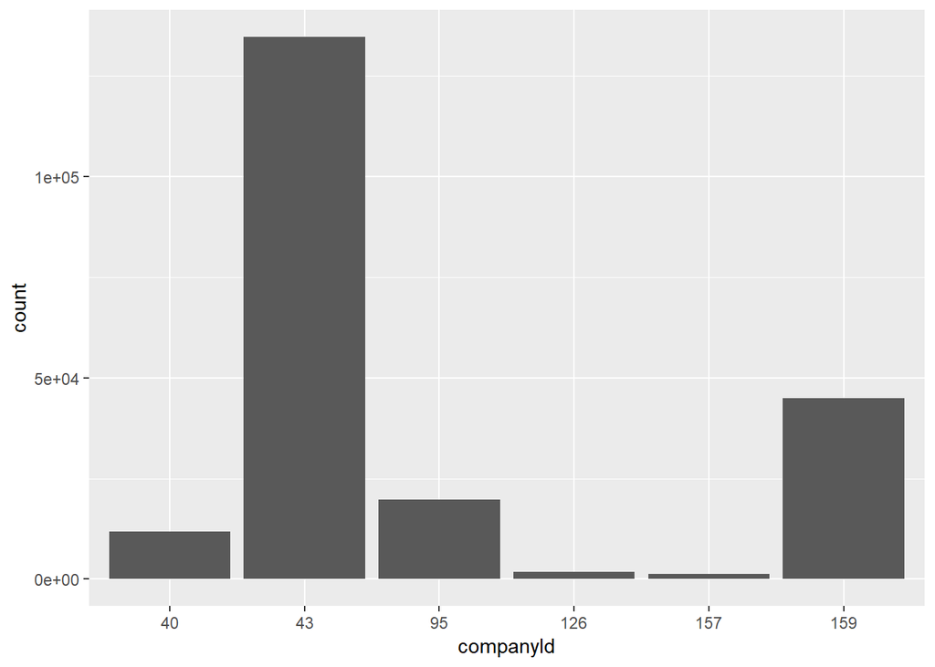

```r
#Categorical Features

#--------------------[Company]----------------------#

company <- advertising_train %>%
    group_by(companyId) %>%
    dplyr::summarise(count=n())

company %>%
    ggplot(aes(x = companyId, y = count)) +
    geom_col()
```

Company:  
The majority of instances belong to Company ID 43.

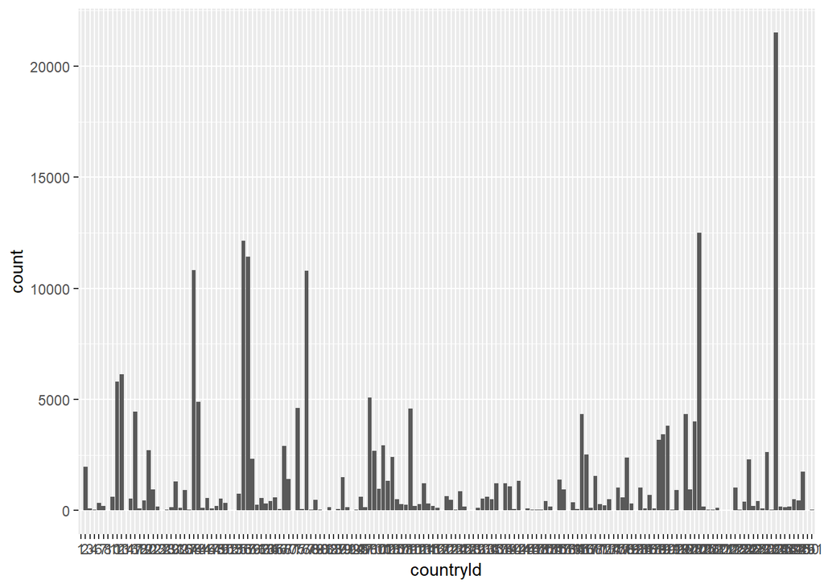

```r
#--------------------[Country]----------------------#

country <- advertising_train %>%
    group_by(countryId) %>%
    dplyr::summarise(count=n())

country %>%
    ggplot(aes(x = countryId, y = count)) +
    geom_col()
```

Country ID:  
We do not have access to the Country ID concordance to country names

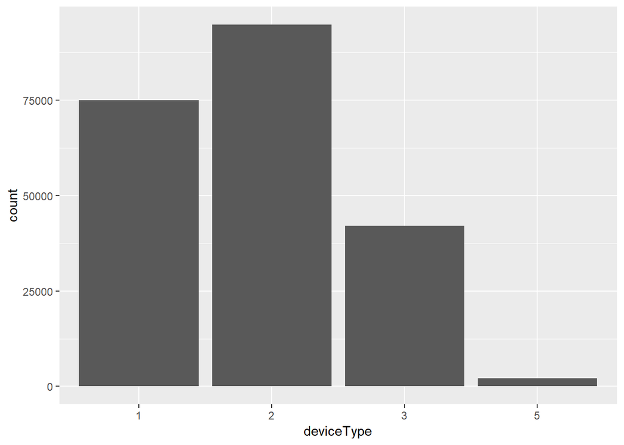

```r
#--------------------[Device Type]----------------------#

device <- advertising_train %>%
    group_by(deviceType) %>%
    dplyr::summarise(count=n())

device %>%
    ggplot(aes(x = deviceType, y = count)) +
    geom_col()
```

Device Type:  
Majority level of device type is 2.

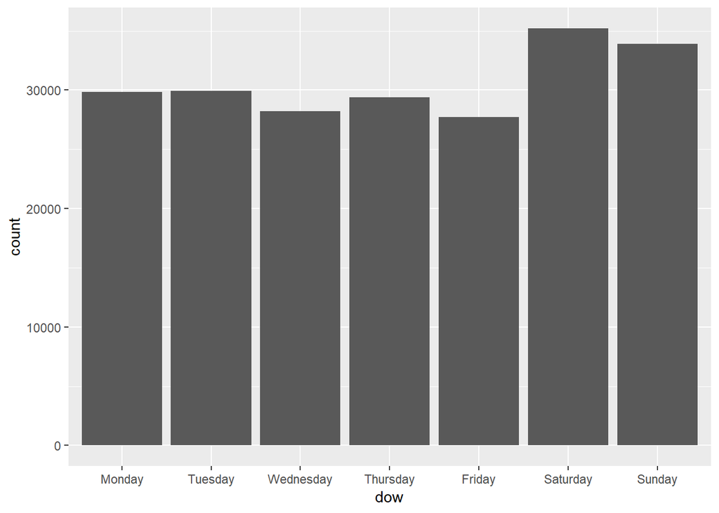

```r
#--------------------[Day of Week]----------------------#

advertising_train$dow <- factor(advertising_train$dow, levels = c('Monday','Tuesday','Wednesday','Thursday','Friday','Saturday','Sunday'))

day.of.week <- advertising_train %>%
    group_by(dow) %>%
    dplyr::summarise(count=n())



day.of.week %>%
    ggplot(aes(x = dow, y = count)) +
    geom_col()
```

Day of Week:  
There is a higher level of instances on Saturday and Sunday.

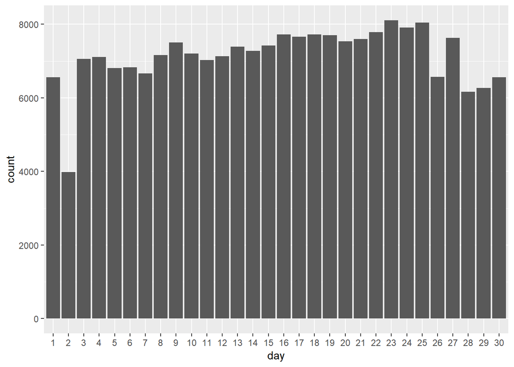

```r
#--------------------[Day]----------------------#

day <- advertising_train %>%
    group_by(day) %>%
    dplyr::summarise(count=n())

day %>%
    ggplot(aes(x = day, y = count)) +
    geom_col()
```

Distribution is largely uniform, with a particularly low number of instances on Day 2.

# Numeric Features

```r
#--------------------[Price 1]----------------------#


price1 <- train$price1
summary(price1)
```

```
##    Min. 1st Qu.  Median    Mean 3rd Qu.    Max.
##  0.0000  0.0000  0.0100  0.4382  0.1900 14.6900
```

```r
train %>%
    group_by(price1) %>%
    dplyr::summarise(count=n())
```

```
## # A tibble: 514 x 2
##    price1 count
##     <dbl> <int>
##  1 0.     92892
##  2 0.0100 19880
##  3 0.0200  6153
##  4 0.0300  3382
##  5 0.0400   842
##  6 0.0500  8714
##  7 0.0600  2750
##  8 0.0700  2591
##  9 0.0800  1842
## 10 0.0900  1463
## # ... with 504 more rows
```

```r
price1_log <- train_log$price1
summary(price1_log)
```

```
##    Min. 1st Qu.  Median    Mean 3rd Qu.    Max.
##  -2.303  -2.303  -2.207  -1.574  -1.238   2.694
```

```r
train_log%>%
    group_by(price1) %>%
    dplyr::summarise(count=n())
```

```
## # A tibble: 514 x 2
##    price1 count
##     <dbl> <int>
##  1  -2.30 92892
##  2  -2.21 19880
##  3  -2.12  6153
##  4  -2.04  3382
##  5  -1.97   842
##  6  -1.90  8714
##  7  -1.83  2750
##  8  -1.77  2591
##  9  -1.71  1842
## 10  -1.66  1463
## # ... with 504 more rows
```

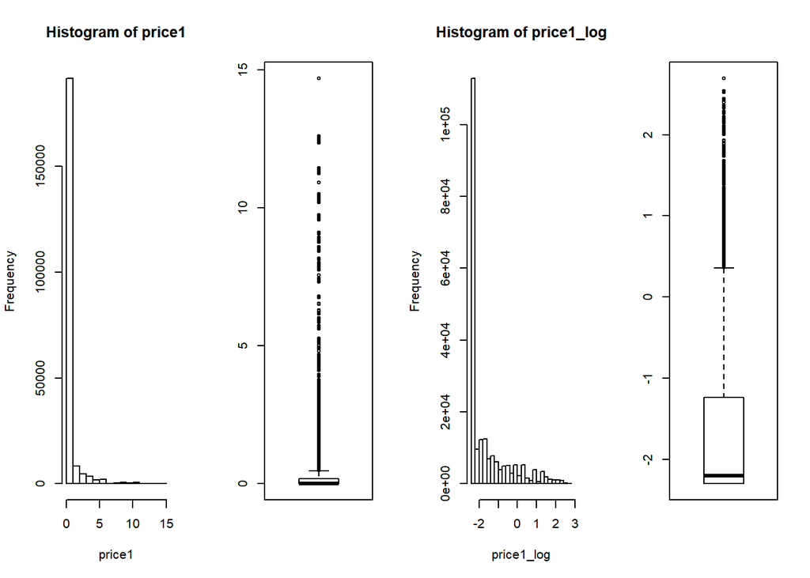

```r
par(mfrow = c(1,4))
hist(price1)
boxplot(price1)

hist(price1_log)
boxplot(price1_log)
```

```r
#--------------------[Price 2]----------------------#


price2 <- train$price2
summary(price2)
```

```
##    Min. 1st Qu.  Median    Mean 3rd Qu.    Max.
##  0.0000  0.0000  0.0900  0.6302  0.5700 63.1200
```

```r
train %>%
    group_by(price2) %>%
    dplyr::summarise(count=n())
```

```
## # A tibble: 744 x 2
##    price2 count
##     <dbl> <int>
##  1 0.     92804
##  2 0.0100   838
##  3 0.0200   314
##  4 0.0300   788
##  5 0.0400    93
##  6 0.0500  4664
##  7 0.0600  1946
##  8 0.0700  2240
##  9 0.0800  2222
## 10 0.0900  2111
## # ... with 734 more rows
```

```r
price2_log <- train_log$price2
summary(price2_log)
```

```
##    Min. 1st Qu.  Median    Mean 3rd Qu.    Max.
## -2.3026 -2.3026 -1.6607 -1.2533 -0.4005  4.1466
```

```r
train_log%>%
    group_by(price2) %>%
    dplyr::summarise(count=n())
```

```
## # A tibble: 744 x 2
##    price2 count
##     <dbl> <int>
##  1  -2.30 92804
##  2  -2.21   838
##  3  -2.12   314
##  4  -2.04   788
##  5  -1.97    93
##  6  -1.90  4664
##  7  -1.83  1946
##  8  -1.77  2240
##  9  -1.71  2222
## 10  -1.66  2111
## # ... with 734 more rows
```

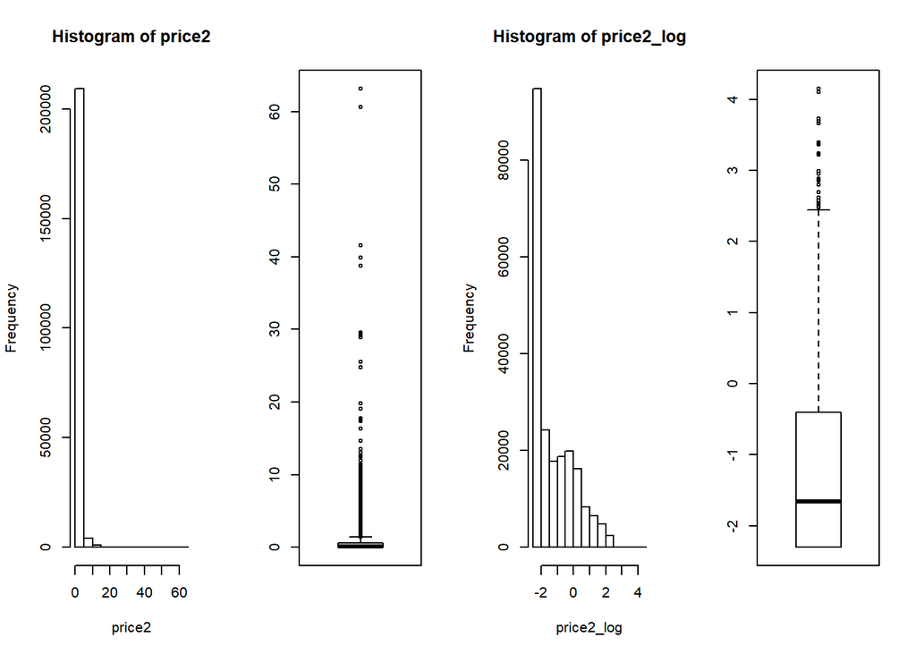

```r
par(mfrow = c(1,4))
hist(price2)
boxplot(price2)

hist(price2_log)
boxplot(price2_log)
```

```r
#--------------------[Price 3]----------------------#

price3 <- train$price3
summary(price3)
```

```
##    Min. 1st Qu.  Median    Mean 3rd Qu.    Max.
##  0.0000  0.0000  0.2948  0.9324  0.9857 78.9000
```

```r
train %>%
    group_by(price3) %>%
    dplyr::summarise(count=n())
```

```
## # A tibble: 5,185 x 2
##    price3 count
##     <dbl> <int>
##  1 0.     92804
##  2 0.0100    35
##  3 0.0500  3331
##  4 0.0800     4
##  5 0.100   1527
##  6 0.110      6
##  7 0.140      1
##  8 0.170      1
##  9 0.200   4561
## 10 0.210      8
## # ... with 5,175 more rows
```

```r
price3_log <- train_log$price3
summary(price3_log)
```

```
##     Min.  1st Qu.   Median     Mean  3rd Qu.     Max.
## -2.30259 -2.30259 -0.92938 -0.97585  0.08218  4.36945
```

```r
train_log%>%
    group_by(price3) %>%
    dplyr::summarise(count=n())
```

```
## # A tibble: 5,185 x 2
##    price3 count
##     <dbl> <int>
##  1  -2.30 92804
##  2  -2.21    35
##  3  -1.90  3331
##  4  -1.71     4
##  5  -1.61  1527
##  6  -1.56     6
##  7  -1.43     1
##  8  -1.31     1
##  9  -1.20  4561
## 10  -1.17     8
## # ... with 5,175 more rows
```

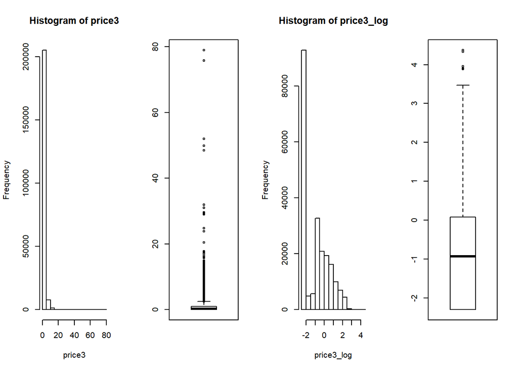

```r
par(mfrow = c(1,4))
hist(price3)
boxplot(price3)

hist(price3_log)
boxplot(price3_log)
```

```r
#--------------------[Ad Area]----------------------#


ad_area <- train$ad_area
summary(ad_area)
```

```
##    Min. 1st Qu.  Median    Mean 3rd Qu.    Max.
##  0.0001  0.0001  0.0001  4.7245  7.5000 36.0000
```

```r
train %>%
    group_by(ad_area) %>%
    dplyr::summarise(count=n())
```

```
## # A tibble: 56 x 2
##     ad_area  count
##       <dbl>  <int>
##  1 0.000100 112028
##  2 1.60       4500
##  3 2.81        431
##  4 3.19         18
##  5 3.20       2762
##  6 3.81         46
##  7 3.84        131
##  8 3.96         60
##  9 4.00         43
## 10 5.10         25
## # ... with 46 more rows
```

```r
ad_area_log <- train_log$ad_area
summary(ad_area_log)
```

```
##    Min. 1st Qu.  Median    Mean 3rd Qu.    Max.
##  -9.210  -9.210  -9.210  -3.797   2.015   3.584
```

```r
train_log%>%
    group_by(ad_area) %>%
    dplyr::summarise(count=n())
```

```
## # A tibble: 56 x 2
##    ad_area  count
##      <dbl>  <int>
##  1  -9.21  112028
##  2   0.470   4500
##  3   1.03     431
##  4   1.16      18
##  5   1.16    2762
##  6   1.34      46
##  7   1.35     131
##  8   1.38      60
##  9   1.39      43
## 10   1.63      25
## # ... with 46 more rows
```

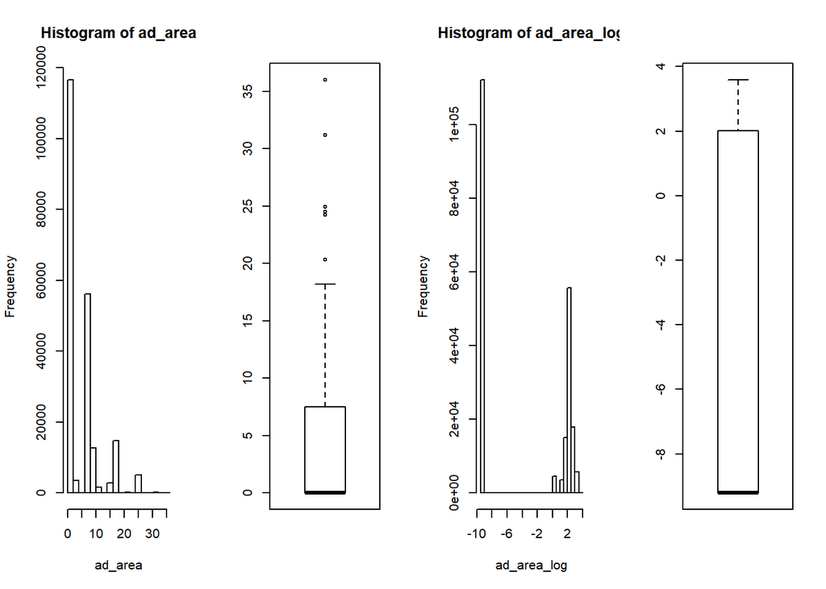

```r
par(mfrow = c(1,4))
hist(ad_area)
boxplot(ad_area)

hist(ad_area_log)
boxplot(ad_area_log)
```

```r
#--------------------[Ad Ratio]----------------------#


ad_ratio <- train$ad_ratio
summary(ad_ratio)
```

```
##    Min. 1st Qu.  Median    Mean 3rd Qu.    Max.
## 0.08333 0.83333 1.00000 0.92340 1.00000 5.00000
```

```r
train %>%
    group_by(ad_ratio) %>%
    dplyr::summarise(count=n())
```

```
## # A tibble: 61 x 2
##    ad_ratio count
##       <dbl> <int>
##  1   0.0833    26
##  2   0.0900    65
##  3   0.0909    60
##  4   0.0928  2108
##  5   0.0938   131
##  6   0.0945    46
##  7   0.102     59
##  8   0.108     22
##  9   0.110     20
## 10   0.114     92
## # ... with 51 more rows
```

```r
ad_ratio_log <- train_log$ad_ratio
summary(ad_ratio_log)
```

```
##    Min. 1st Qu.  Median    Mean 3rd Qu.    Max.
## -2.4849 -0.1823  0.0000 -0.2616  0.0000  1.6094
```

```r
train_log%>%
    group_by(ad_ratio) %>%
    dplyr::summarise(count=n())
```

```
## # A tibble: 61 x 2
##    ad_ratio count
##       <dbl> <int>
##  1    -2.48    26
##  2    -2.41    65
##  3    -2.40    60
##  4    -2.38  2108
##  5    -2.37   131
##  6    -2.36    46
##  7    -2.28    59
##  8    -2.22    22
##  9    -2.20    20
## 10    -2.17    92
## # ... with 51 more rows
```

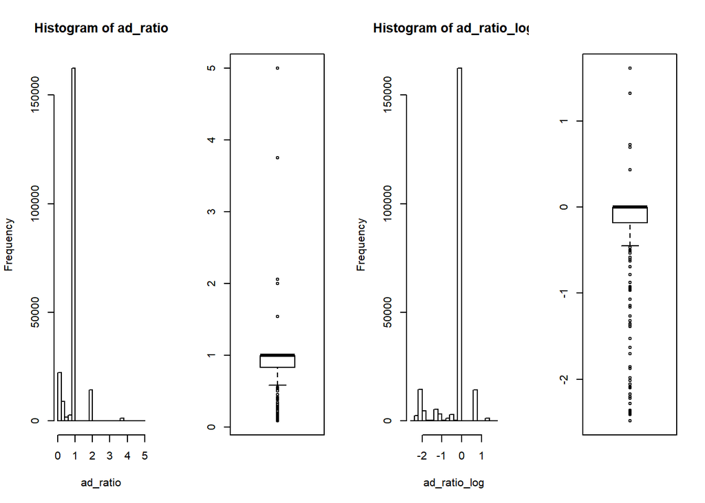

```r
par(mfrow = c(1,4))
hist(ad_ratio)
boxplot(ad_ratio)

hist(ad_ratio_log)
boxplot(ad_ratio_log)
```

Ad Area:

The description of this feature states that it has been normalised between 0 and 1. The majority of values are extremely small (0.001) or over 1, which is not consistent with this description. However, without more information regarding the data, we are reluctant to adjust the data further we are unsure if there is an error in the description or the normalised calculation. This will be further investigated in Phase 2 and adjustments will be made if necessary.

Ad Ratio:

The description of this feature stats that it has been normalised between 0 and 1. In comparison to Ad Area, the distribution does appear to largely fall within 0 and 1, with a median value of 1. There are a small number of instances with values greater than 1. Similar to Ad Area, without further information regarding the data, it is difficult to say with certainty that these are outliers so we have decided not to constrain the data using winsorisation. This will be further evaluated during modelling and adjusted if necessary.

The log transformation does not do much to normalise the distribution of the data.

```r
#--------------------[Requests]----------------------#



requests <- train$requests
summary(requests)
```

```
##    Min. 1st Qu.  Median    Mean 3rd Qu.    Max.
##       0       0     147    8679    1633 6701924
```

```r
train %>%
    group_by(requests) %>%
    dplyr::summarise(count=n())
```

```
## # A tibble: 23,711 x 2
##    requests count
##       <int> <int>
##  1        0 78874
##  2        3   343
##  3        4   412
##  4        5   403
##  5        6   427
##  6        7   414
##  7        8   422
##  8        9   400
##  9       10   397
## 10       11   393
## # ... with 23,701 more rows
```

```r
requests_log <- train_log$requests
summary(requests_log)
```

```
##    Min. 1st Qu.  Median    Mean 3rd Qu.    Max.
##  -2.303  -2.303   4.991   3.441   7.398  15.718
```

```r
train_log%>%
    group_by(requests) %>%
    dplyr::summarise(count=n())
```

```
## # A tibble: 23,711 x 2
##    requests count
##       <dbl> <int>
##  1    -2.30 78874
##  2     1.13   343
##  3     1.41   412
##  4     1.63   403
##  5     1.81   427
##  6     1.96   414
##  7     2.09   422
##  8     2.21   400
##  9     2.31   397
## 10     2.41   393
## # ... with 23,701 more rows
```

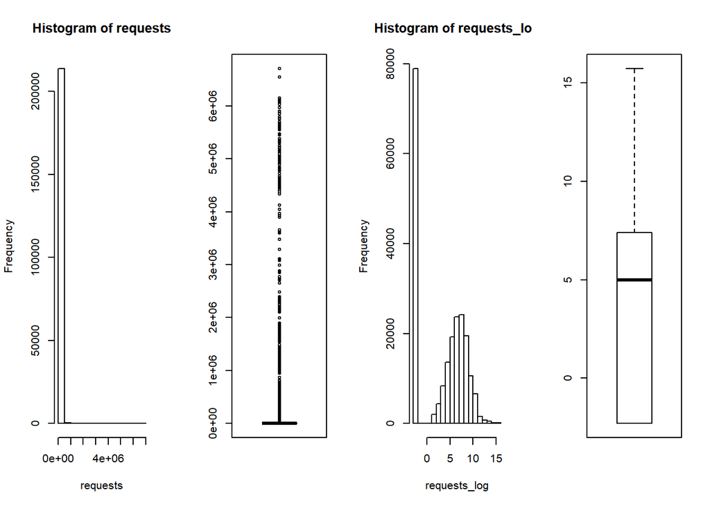

```r
par(mfrow = c(1,4))
hist(requests)
boxplot(requests)

hist(requests_log)
boxplot(requests_log)
```

```r
#--------------------[Impression]----------------------#



impression <- train$impression
summary(impression)
```

```
##    Min. 1st Qu.  Median    Mean 3rd Qu.    Max.
##       0       0      99    5586    1058 6100324
```

```r
train %>%
    group_by(impression) %>%
    dplyr::summarise(count=n())
```

```
## # A tibble: 17,904 x 2
##    impression count
##         <int> <int>
##  1          0 78874
##  2          1    89
##  3          2   200
##  4          3   493
##  5          4   608
##  6          5   617
##  7          6   586
##  8          7   569
##  9          8   582
## 10          9   496
## # ... with 17,894 more rows
```

```r
impression_log <- train_log$impression
summary(impression_log)
```

```
##    Min. 1st Qu.  Median    Mean 3rd Qu.    Max.
##  -2.303  -2.303   4.596   3.154   6.964  15.624
```

```r
train_log%>%
    group_by(impression) %>%
    dplyr::summarise(count=n())
```

```
## # A tibble: 17,904 x 2
##    impression count
##         <dbl> <int>
##  1    -2.30   78874
##  2     0.0953    89
##  3     0.742    200
##  4     1.13     493
##  5     1.41     608
##  6     1.63     617
##  7     1.81     586
##  8     1.96     569
##  9     2.09     582
## 10     2.21     496
## # ... with 17,894 more rows
```

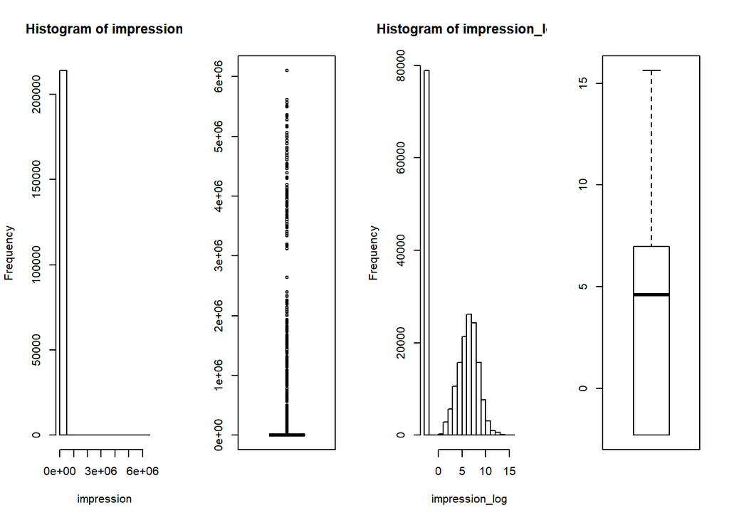

```r
par(mfrow = c(1,4))
hist(impression)
boxplot(impression)

hist(impression_log)
boxplot(impression_log)
```

Requests and Impression:

The log transformation improves the distribution of the data.

```r
#--------------------[CPC - Cost per click]----------------------#

cpc <- train$cpc
summary(cpc)
```

```
##     Min.  1st Qu.   Median     Mean  3rd Qu.     Max.
##   0.0000   0.0000   0.0157   0.1779   0.1252 132.5339
```

```r
train %>%
    group_by(cpc) %>%
    dplyr::summarise(count=n())
```

```
## # A tibble: 15,670 x 2
##         cpc count
##       <dbl> <int>
##  1 0.       78913
##  2 0.000100   278
##  3 0.000200   236
##  4 0.000300   197
##  5 0.000400   264
##  6 0.000500   210
##  7 0.000600   268
##  8 0.000700   194
##  9 0.000800   232
## 10 0.000900   198
## # ... with 15,660 more rows
```

```r
cpc_log <- train_log$cpc
summary(cpc_log)
```

```
##    Min. 1st Qu.  Median    Mean 3rd Qu.    Max.
##  -2.303  -2.303  -2.157  -1.773  -1.491   4.888
```

```r
train_log%>%
    group_by(cpc) %>%
    dplyr::summarise(count=n())
```

```
## # A tibble: 15,670 x 2
##      cpc count
##    <dbl> <int>
##  1 -2.30 78913
##  2 -2.30   278
##  3 -2.30   236
##  4 -2.30   197
##  5 -2.30   264
##  6 -2.30   210
##  7 -2.30   268
##  8 -2.30   194
##  9 -2.29   232
## 10 -2.29   198
## # ... with 15,660 more rows
```

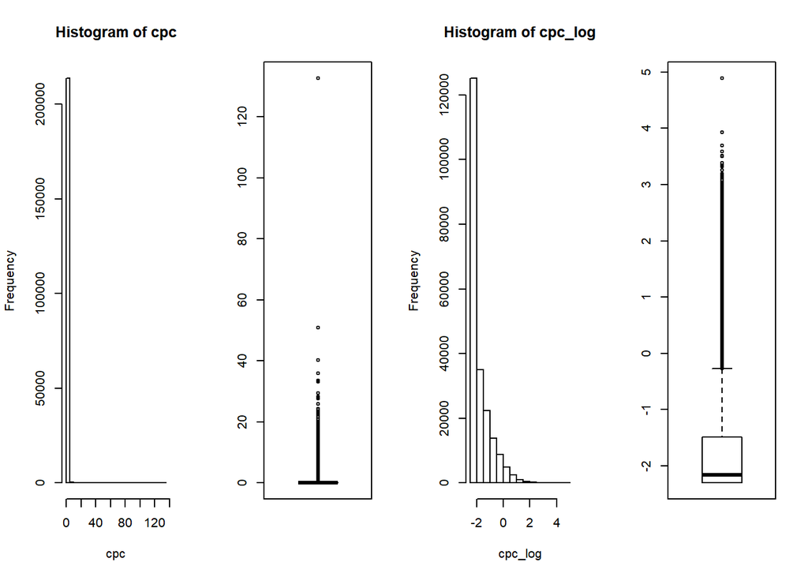

```r
par(mfrow = c(1,4))
hist(cpc)
boxplot(cpc)

hist(cpc_log)
boxplot(cpc_log)
```

```r
#--------------------[CTR - click through rate]----------------------#


ctr <- train$ctr
summary(ctr)
```

```
##    Min. 1st Qu.  Median    Mean 3rd Qu.    Max.
## 0.00000 0.00000 0.00170 0.03292 0.01200 2.00000
```

```r
train %>%
    group_by(ctr) %>%
    dplyr::summarise(count=n())
```

```
## # A tibble: 4,277 x 2
##         ctr count
##       <dbl> <int>
##  1 0.       78957
##  2 0.000100   459
##  3 0.000200  1080
##  4 0.000300  1517
##  5 0.000400  1779
##  6 0.000500  1842
##  7 0.000600  1987
##  8 0.000700  2043
##  9 0.000800  2042
## 10 0.000900  1978
## # ... with 4,267 more rows
```

```r
ctr_log <- train_log$ctr
summary(ctr_log)
```

```
##    Min. 1st Qu.  Median    Mean 3rd Qu.    Max.
## -2.3026 -2.3026 -2.2857 -2.1223 -2.1893  0.7419
```

```r
train_log%>%
    group_by(ctr) %>%
    dplyr::summarise(count=n())
```

```
## # A tibble: 4,277 x 2
##      ctr count
##    <dbl> <int>
##  1 -2.30 78957
##  2 -2.30   459
##  3 -2.30  1080
##  4 -2.30  1517
##  5 -2.30  1779
##  6 -2.30  1842
##  7 -2.30  1987
##  8 -2.30  2043
##  9 -2.29  2042
## 10 -2.29  1978
## # ... with 4,267 more rows
```

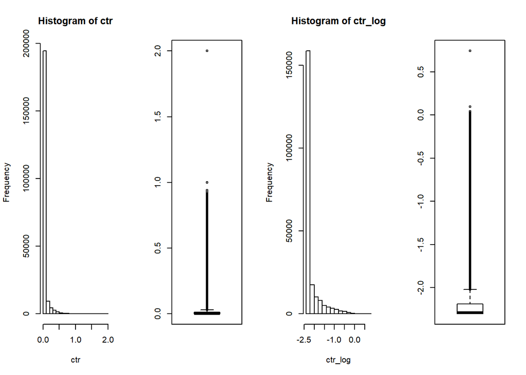

```r
par(mfrow = c(1,4))
hist(ctr)
boxplot(ctr)

hist(ctr_log)
boxplot(ctr_log)
```

Cost Per Click (CPC) and Click Through Rate (CTR):

```r
#--------------------[Viewability]----------------------#

viewability <- train$viewability
summary(viewability)
```

```
##    Min. 1st Qu.  Median    Mean 3rd Qu.    Max.
##  0.0000  0.0000  0.3315  0.3779  0.7159  7.0000
```

```r
train %>%
    group_by(viewability) %>%
    dplyr::summarise(count=n())
```

```
## # A tibble: 10,533 x 2
##    viewability count
##          <dbl> <int>
##  1    0.       79754
##  2    0.000400     2
##  3    0.000500     1
##  4    0.000600     2
##  5    0.000700     4
##  6    0.000800     3
##  7    0.000900     6
##  8    0.00100      3
##  9    0.00110      2
## 10    0.00120      2
## # ... with 10,523 more rows
```

```r
viewability_log <- train_log$viewability
summary(viewability_log)
```

```
##    Min. 1st Qu.  Median    Mean 3rd Qu.    Max.
## -2.3026 -2.3026 -0.8405 -1.1468 -0.2035  1.9601
```

```r
train_log%>%
    group_by(viewability) %>%
    dplyr::summarise(count=n())
```

```
## # A tibble: 10,533 x 2
##    viewability count
##          <dbl> <int>
##  1       -2.30 79754
##  2       -2.30     2
##  3       -2.30     1
##  4       -2.30     2
##  5       -2.30     4
##  6       -2.29     3
##  7       -2.29     6
##  8       -2.29     3
##  9       -2.29     2
## 10       -2.29     2
## # ... with 10,523 more rows
```

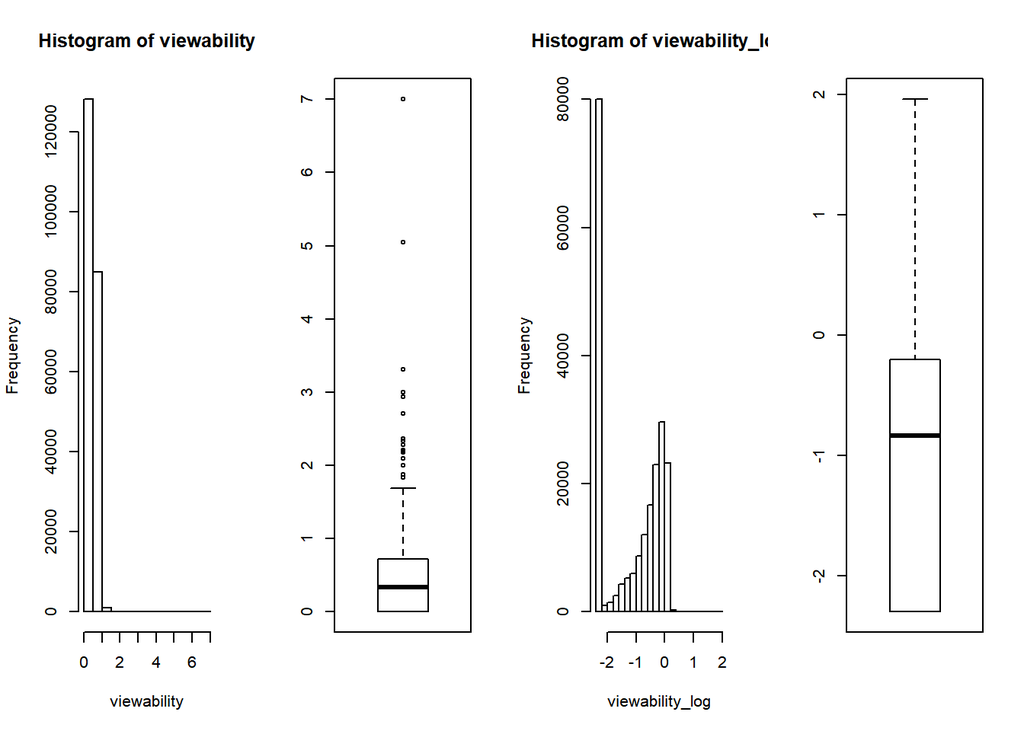

```r
par(mfrow = c(1,4))
hist(viewability)
boxplot(viewability)

hist(viewability_log)
boxplot(viewability_log)
```

Viewability:

```r
#--------------------[Ratio 1]----------------------#

summary(advertising_train$ratio1)
```

```
##    Min. 1st Qu.  Median    Mean 3rd Qu.    Max.
##  0.0000  0.0000  0.7500  0.5583  1.0000  1.0000
```

```r
advertising_train %>%
    group_by(ratio1) %>%
    dplyr::summarise(count=n())
```

```
## # A tibble: 7,325 x 2
##      ratio1 count
##       <dbl> <int>
##  1 0.       78920
##  2 0.000300     1
##  3 0.000500     1
##  4 0.000600     1
##  5 0.000800     3
##  6 0.00100      1
##  7 0.00110      1
##  8 0.00120      1
##  9 0.00130      1
## 10 0.00160      1
## # ... with 7,315 more rows
```

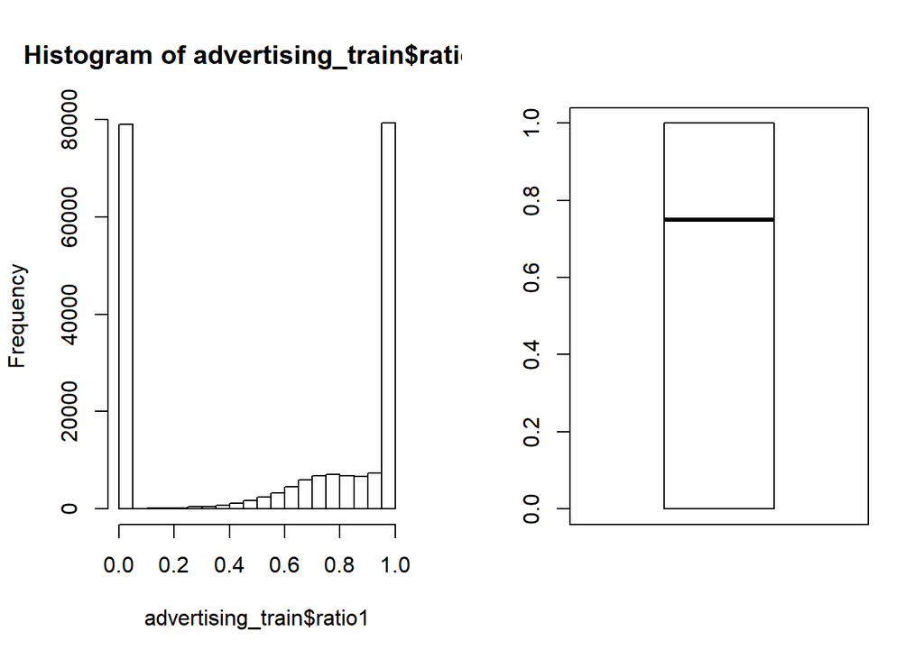

```r
par(mfrow = c(1,2))
hist(advertising_train$ratio1)
boxplot(advertising_train$ratio1)
```

```r
#--------------------[Ratio 2]----------------------#

summary(advertising_train$ratio2)
```

```
##    Min. 1st Qu.  Median    Mean 3rd Qu.    Max.
##  0.0000  0.0000  0.6271  0.4911  0.8957  1.0270
```

```r
advertising_train %>%
    group_by(ratio2) %>%
    dplyr::summarise(count=n())
```

```
## # A tibble: 9,418 x 2
##      ratio2 count
##       <dbl> <int>
##  1 0.       78874
##  2 0.000100     2
##  3 0.000500     1
##  4 0.000600     2
##  5 0.000700     1
##  6 0.000800     1
##  7 0.000900     2
##  8 0.00100      1
##  9 0.00110      1
## 10 0.00120      1
## # ... with 9,408 more rows
```

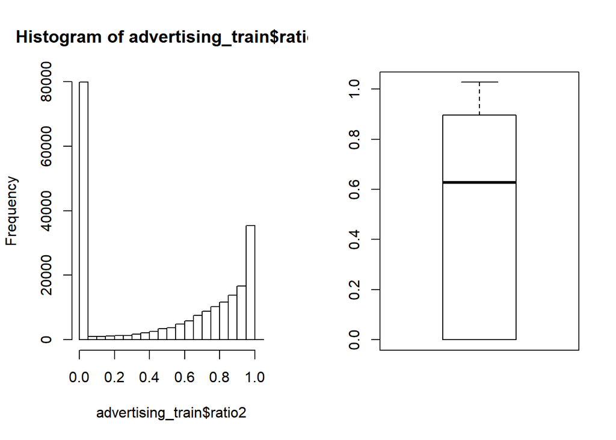

```r
par(mfrow = c(1,2))
hist(advertising_train$ratio2)
boxplot(advertising_train$ratio2)
```

```r
#--------------------[Ratio 3]----------------------#

summary(advertising_train$ratio3)
```

```
##    Min. 1st Qu.  Median    Mean 3rd Qu.    Max.
##  0.0000  0.0000  0.0276  0.3116  1.0000  1.5000
```

```r
advertising_train %>%
    group_by(ratio3) %>%
    dplyr::summarise(count=n())
```

```
## # A tibble: 4,358 x 2
##      ratio3 count
##       <dbl> <int>
##  1 0.       94578
##  2 0.000100     2
##  3 0.000200    14
##  4 0.000300    12
##  5 0.000400    26
##  6 0.000500    23
##  7 0.000600    30
##  8 0.000700    32
##  9 0.000800    44
## 10 0.000900    25
## # ... with 4,348 more rows
```

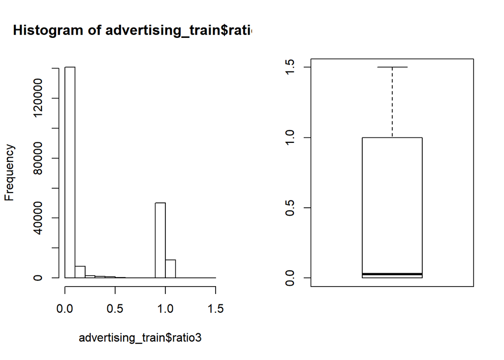

```r
par(mfrow = c(1,2))
hist(advertising_train$ratio3)
boxplot(advertising_train$ratio3)
```

```r
#--------------------[Ratio 4]----------------------#

summary(advertising_train$ratio4)
```

```
##    Min. 1st Qu.  Median    Mean 3rd Qu.    Max.
##  0.0000  0.0000  0.0000  0.1310  0.1636  1.0769
```

```r
advertising_train %>%
    group_by(ratio4) %>%
    dplyr::summarise(count=n())
```

```
## # A tibble: 9,615 x 2
##      ratio4  count
##       <dbl>  <int>
##  1 0.       144465
##  2 0.000200      1
##  3 0.00160       1
##  4 0.00170       1
##  5 0.00200       1
##  6 0.00210       1
##  7 0.00230       2
##  8 0.00250       2
##  9 0.00260       5
## 10 0.00270       1
## # ... with 9,605 more rows
```

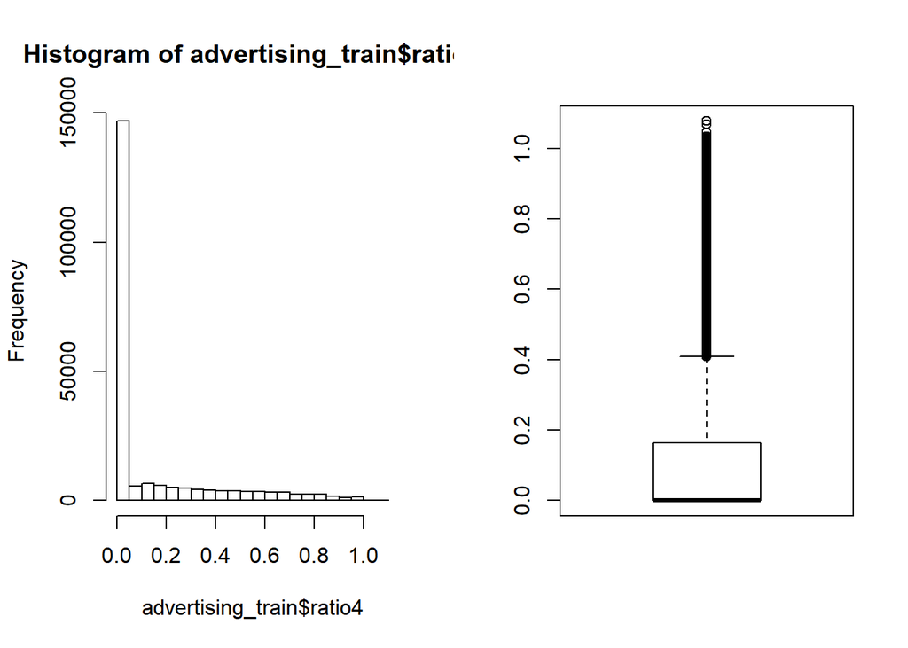

```r
par(mfrow = c(1,2))
hist(advertising_train$ratio4)
boxplot(advertising_train$ratio4)
```

```r
#--------------------[Ratio 5]----------------------#

summary(advertising_train$ratio5)
```

```
##    Min. 1st Qu.  Median    Mean 3rd Qu.    Max.
##  0.0000  0.0000  0.0000  0.1883  0.3847  1.2000
```

```r
advertising_train %>%
    group_by(ratio5) %>%
    dplyr::summarise(count=n())
```

```
## # A tibble: 9,315 x 2
##     ratio5  count
##      <dbl>  <int>
##  1 0.      142295
##  2 0.00170      1
##  3 0.00220      1
##  4 0.00270      1
##  5 0.00290      1
##  6 0.00330      1
##  7 0.00440      1
##  8 0.00490      1
##  9 0.00510      1
## 10 0.00530      1
## # ... with 9,305 more rows
```

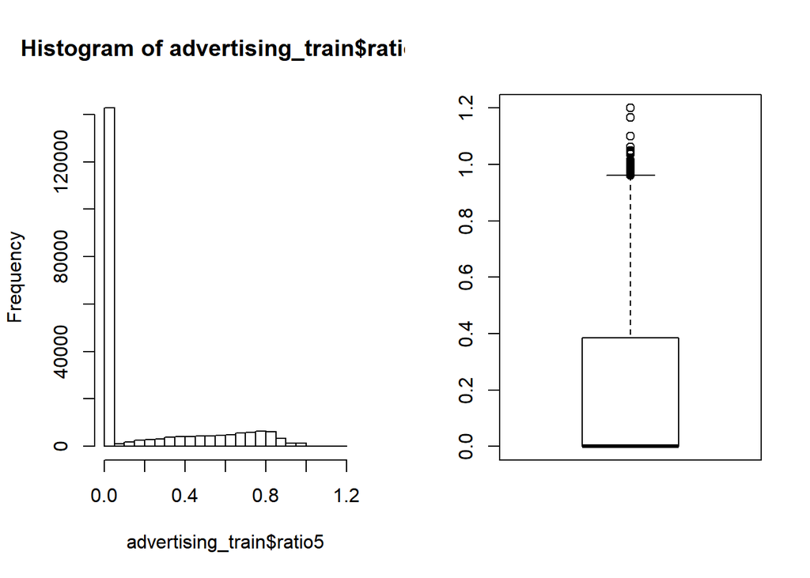

```r
par(mfrow = c(1,2))
hist(advertising_train$ratio5)
boxplot(advertising_train$ratio5)
```

Ratio Features:

```r
#--------------------[Target Variable (y)]----------------------#

y <- train$y
summary(y)
```

```
##    Min. 1st Qu.  Median    Mean 3rd Qu.    Max.
##  0.0001  0.1504  0.4190  0.8470  0.9590 47.0600
```

```r
train %>%
    group_by(y) %>%
    dplyr::summarise(count=n())
```

```
## # A tibble: 167,458 x 2
##            y count
##        <dbl> <int>
##  1 0.0000979     1
##  2 0.000151      1
##  3 0.000168      1
##  4 0.000193      1
##  5 0.000213      1
##  6 0.000261      1
##  7 0.000297      1
##  8 0.000372      1
##  9 0.000403      1
## 10 0.000413      1
## # ... with 167,448 more rows
```

```r
y_log <- train_log$y
summary(y_log)
```

```
##     Min.  1st Qu.   Median     Mean  3rd Qu.     Max.
## -9.23156 -1.89435 -0.86988 -1.00551 -0.04181  3.85142
```

```r
train_log%>%
    group_by(y) %>%
    dplyr::summarise(count=n())
```

```
## # A tibble: 167,458 x 2
##        y count
##    <dbl> <int>
##  1 -9.23     1
##  2 -8.80     1
##  3 -8.69     1
##  4 -8.55     1
##  5 -8.45     1
##  6 -8.25     1
##  7 -8.12     1
##  8 -7.90     1
##  9 -7.82     1
## 10 -7.79     1
## # ... with 167,448 more rows
```

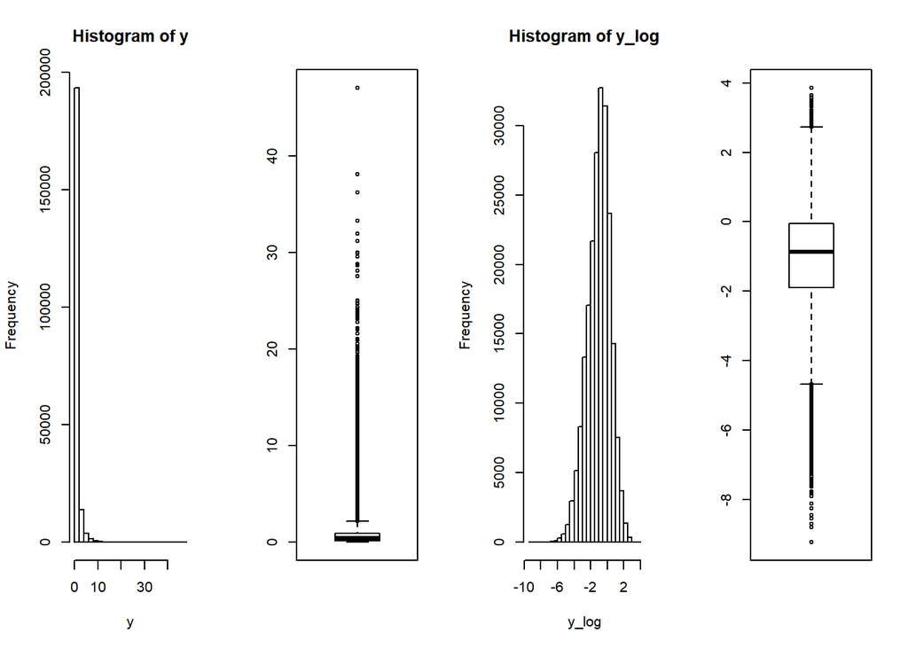

```r
par(mfrow = c(1,4))
hist(y)
boxplot(y)

hist(y_log)
boxplot(y_log)
```

Target Feature (y):

The majority of values fall below 1, while the maximum value is 47, resulting in highly positively skewed data. By applying a log transformation to the target feature, the distribution is greatly improved in terms of normality. For creating a machine learning model, we will use log transformed values of y. This means that once the model is determined and predictions are calculated, they will have to be returned from log values to original values.

### Multivariate

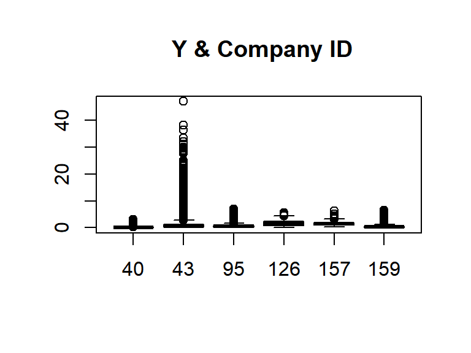

```r
par(mfrow = c(1,1))

y <- advertising_train$y

boxplot(y~advertising_train$companyId, main = " Y & Company ID") #Largest spread of y values for Company ID 43 which had the largest number of instances
```

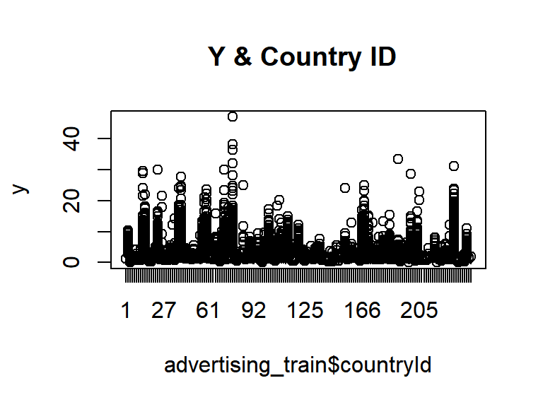

```r
plot(y~advertising_train$countryId, main = " Y & Country ID")
```

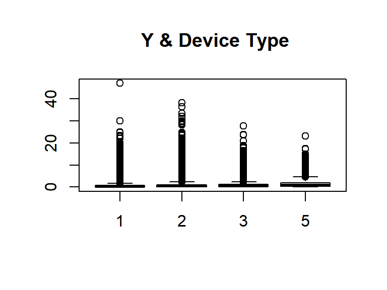

```r
boxplot(y~advertising_train$deviceType, main = " Y & Device Type")
```

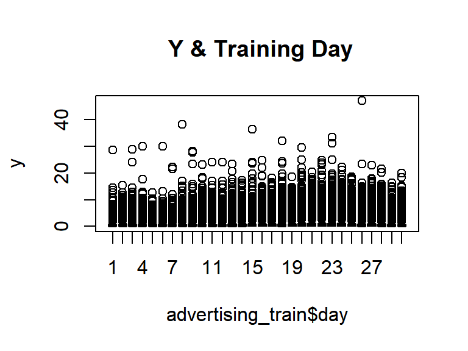

```r
plot(y~advertising_train$day, main = " Y & Training Day")
```

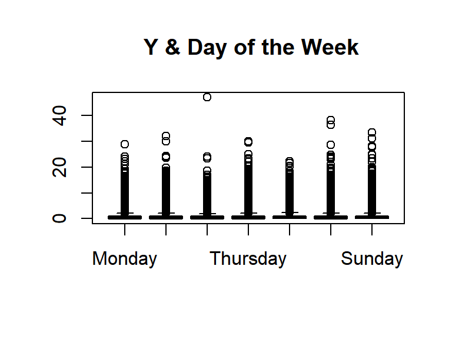

```r
boxplot(y~advertising_train$dow, main = " Y & Day of the Week")
```

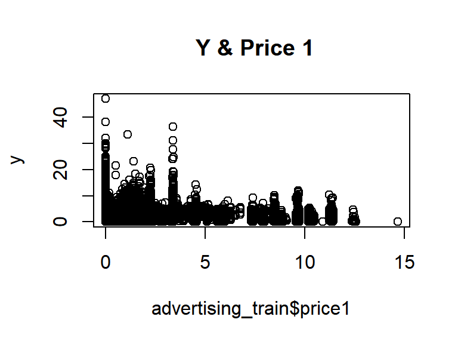

```r
plot(y~advertising_train$price1, main = " Y & Price 1")
```

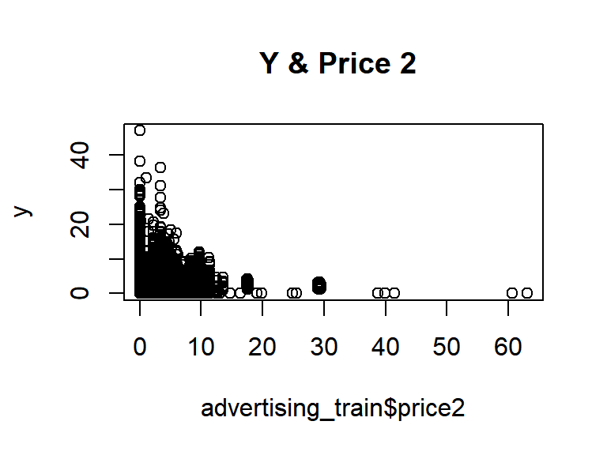

```r
plot(y~advertising_train$price2, main = " Y & Price 2")
```